# Mapping Ambiguity in Vector-Space

May 6, 2020

# Introduction

Klepousniotou et al (2008) and Brown (2008) both showed that the ease of transitioning between two senses of a polysemous word depends on their **degree of overlap**. That is, there is less inhibition (greater facilitation) between *marinated lamb* and *baby lamb* than between *control panel* and *advisory panel*. They measured priming *within* a sense category as a comparison, e.g., between *marinated lamb* and *tender lamb*. Klepousniotou et al (2008) also analyzed an interaction with sense **dominance**, but I will not be analyzing that here.

In the current analyses, I adapted most of their stimuli to sentences, e.g., "He liked the marinated lamb" vs. "He liked the baby lamb". I also created new stimuli using homonyms from Klepousniotou & Baum (2007).

I then ran each sentence through ELMo and BERT and obtained contextualized embeddings for the target word, e.g., *lamb*. Finally, I computed the `cosine distance` between the two embeddings. This allows us to make several comparisons:

First, is `cosine distance` consistently larger for usages occurring *across* senses? That is, is $cos(lamb_{marinated}, lamb_{baby}) > cos(lamb_{marinated}, lamb_{tender})$? If so, it suggests that the contextualized embeddings distinguish between contexts of use in such a way as to correlate with sense boundaries.

Second: for usages occurring *across* senses (e.g., *baby/marinated lamb*), does `cosine distance` vary as a function of `ambiguity type` (e.g., `polysemy` vs. `homonymy`)?

Our data thus looks as follows: each observation represents a comparison (`cosine distance`) between two identical wordforms appearing in different contexts. 1/3 of these observations reflect **same sense** contexts; 2/3 reflect **different sense** contexts. Furthermore, `condition` reflects the degree of overlap between the different sense-contexts.

Random factors include:

- Each `word`
- The `model`

For `word`, we include by-factor random slopes for the effect of `same sense`.

# Load data

```r
df_distances = read_csv("../../data/processed/stims_with_nlm_distances.csv")
nrow(df_distances)
```

```
## [1] 690
```

We leave out items for which it was unclear whether the different versions were truly different senses. **TODO**: Discuss with Ben about this approach.

```r
df_distances = df_distances %>%
  filter(ambiguity_type != "Unsure")
nrow(df_distances)
```

```
## [1] 672
```

```r
length(unique(df_distances$word))
```

```
## [1] 112
```

```r
table(df_distances$same)
```

```
##
## FALSE  TRUE
##   448   224
```

```r
table(df_distances$same) / nrow(df_distances)
```

```
##
##     FALSE      TRUE
## 0.6666667 0.3333333
```

```r
table(df_distances$ambiguity_type) / 6
```

```
##
## Homonymy Polysemy
##       38       74
```

```r
table(df_distances$ambiguity_type, df_distances$Class) / 6
```

```
##
##             N  V
##   Homonymy 31  7
##   Polysemy 53 21
```

# Primary analyses

## Comparing BERT and ELMo distances

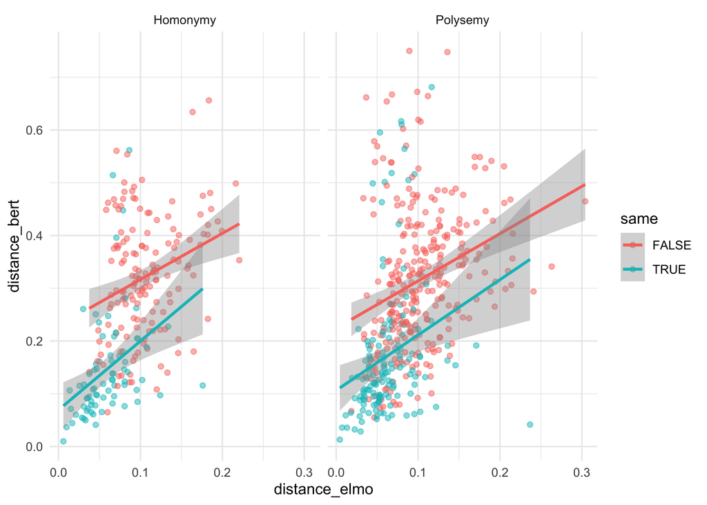

```r
df_distances %>%
  ggplot(aes(x = distance_elmo,
             y = distance_bert,
             color = same)) +
  geom_point(alpha = .5) +
  theme_minimal() +
  geom_smooth(method = "lm") +
  facet_grid(~ambiguity_type)
```

```r
cor.test(df_distances$distance_bert,
         df_distances$distance_elmo,
         method = 'spearman')
```

```
##
##  Spearman's rank correlation rho
##
## data:  df_distances$distance_bert and df_distances$distance_elmo
## S = 23277112, p-value < 2.2e-16
## alternative hypothesis: true rho is not equal to 0
## sample estimates:
##       rho
## 0.5397715
```

## Is cosine distance larger for usages across senses?

First, we ask whether the existence of a sense boundary explains significant variance in the `cosine distance` between two words.

In this analysis, we add a random effect for the `model` being used to assess cosine distance.

```r
df_distances_reshaped = df_distances %>%
  mutate(elmo = distance_elmo,
         bert = distance_bert) %>%
  pivot_longer(c(elmo, bert), names_to = "model",
               values_to = "distance")

model_same = lmer(data = df_distances_reshaped,
                  distance ~ same +
                    Class +
                    (1 | model) +
                    (1 + same | word),
                  control=lmerControl(optimizer="bobyqa"),
                  REML=FALSE)

model_reduced = lmer(data = df_distances_reshaped,
                  distance ~
                    Class +
                    (1 | model) +
                    (1 + same | word),
                  control=lmerControl(optimizer="bobyqa"),
                  REML=FALSE)

summary(model_same)
```

```
## Linear mixed model fit by maximum likelihood  ['lmerMod']
## Formula: distance ~ same + Class + (1 | model) + (1 + same | word)
##    Data: df_distances_reshaped
## Control: lmerControl(optimizer = "bobyqa")
##
##      AIC      BIC   logLik deviance df.resid
##  -2635.6  -2593.9   1325.8  -2651.6     1336
##
## Scaled residuals:
##     Min      1Q  Median      3Q     Max
## -2.6646 -0.5966 -0.0210  0.4393  5.1259
##
## Random effects:
##  Groups   Name        Variance Std.Dev. Corr
##  word     (Intercept) 0.002891 0.05377
##           sameTRUE    0.001107 0.03328  -0.99
##  model    (Intercept) 0.007822 0.08844
##  Residual             0.007112 0.08433
## Number of obs: 1344, groups:  word, 112; model, 2
##
## Fixed effects:
##              Estimate Std. Error t value
## (Intercept)  0.213266   0.062853   3.393
## sameTRUE    -0.099220   0.005805 -17.091
## ClassV      -0.004643   0.009522  -0.488
##
## Correlation of Fixed Effects:
##          (Intr) smTRUE
## sameTRUE -0.065
## ClassV   -0.038  0.000
```

```r
anova(model_same, model_reduced)
```

```
## Data: df_distances_reshaped
## Models:
## model_reduced: distance ~ Class + (1 | model) + (1 + same | word)
## model_same: distance ~ same + Class + (1 | model) + (1 + same | word)
##               npar     AIC     BIC logLik deviance  Chisq Df Pr(>Chisq)
## model_reduced    7 -2493.8 -2457.4 1253.9  -2507.8
## model_same       8 -2635.6 -2593.9 1325.8  -2651.6 143.72  1  < 2.2e-16 ***
## ---
## Signif. codes:  0 '***' 0.001 '**' 0.01 '*' 0.05 '.' 0.1 ' ' 1
```

We find that it does. We can illustrate this visually as well:

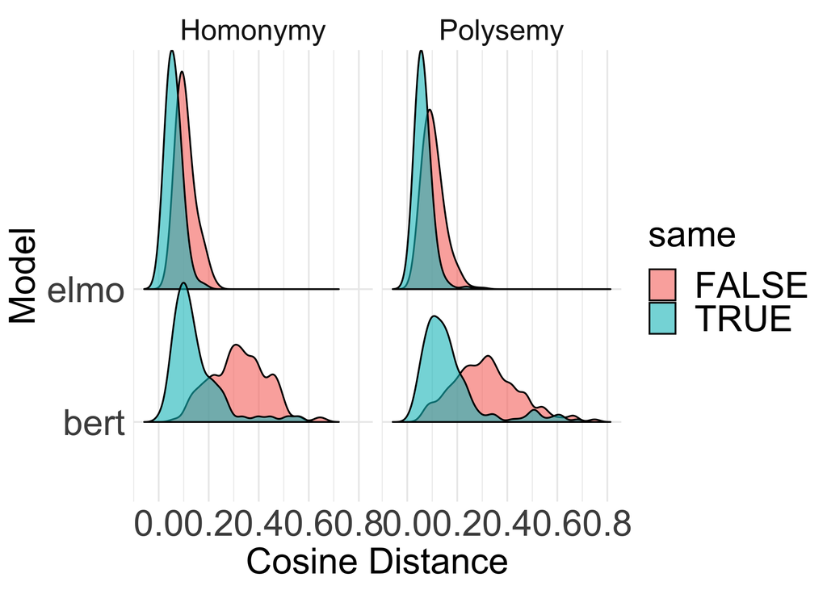

```r
df_distances_reshaped %>%
  ggplot(aes(x = distance,
             fill = same,
             y = model)) +
  geom_density_ridges2(alpha = .6) +
  theme_minimal() +
  labs(x = "Cosine Distance",
       y = "Model") +
  facet_wrap(~ambiguity_type)+
  theme(axis.title = element_text(size=rel(2)),
        axis.text = element_text(size = rel(2)),
        legend.text = element_text(size = rel(2)),
        legend.title = element_text(size = rel(2)),
        strip.text.x = element_text(size = rel(2)))
```

```r
ggsave("../../Figures/cosine_distances.pdf", dpi = 300)
```

## Does cosine distance vary as a function of the type of ambiguity?

Above, we saw that the cosine distance between two usages varied as a function of whether those usages belonged to the same sense.

We also show that a model with both `condition` and `same` does not explain more variance than a model with only `same`; we don't really expect it to, given that `same sense` pairs are included here.

```r
model_both = lmer(data = df_distances_reshaped,
                  distance ~ same +
                    Class +
                    ambiguity_type +
                    (1 | model) +
                    (1 + same | word),
                  control=lmerControl(optimizer="bobyqa"),
                  REML=FALSE)
```

```
## boundary (singular) fit: see ?isSingular
```

```r
anova(model_both, model_same)
```

```
## Data: df_distances_reshaped
## Models:
## model_same: distance ~ same + Class + (1 | model) + (1 + same | word)
## model_both: distance ~ same + Class + ambiguity_type + (1 | model) + (1 +
## model_both:     same | word)
##            npar     AIC     BIC logLik deviance  Chisq Df Pr(>Chisq)
## model_same    8 -2635.6 -2593.9 1325.8  -2651.6
## model_both    9 -2634.7 -2587.8 1326.3  -2652.7 1.0846  1     0.2977
```

But there is also no significant interaction between `condition` and `same` (though it is marginal / trending)

```r
model_interaction = lmer(data = df_distances_reshaped,
                     distance ~ ambiguity_type * same +
                       Class +
                    (1 | model) +
                    (1 + same | word),
                     control=lmerControl(optimizer="bobyqa"),
                     REML=FALSE)
```

```
## boundary (singular) fit: see ?isSingular
```

```r
anova(model_both, model_interaction)
```

```
## Data: df_distances_reshaped
## Models:
## model_both: distance ~ same + Class + ambiguity_type + (1 | model) + (1 +
## model_both:     same | word)
## model_interaction: distance ~ ambiguity_type * same + Class + (1 | model) + (1 +
## model_interaction:     same | word)
##                   npar     AIC     BIC logLik deviance  Chisq Df Pr(>Chisq)
## model_both           9 -2634.7 -2587.8 1326.3  -2652.7
## model_interaction   10 -2634.8 -2582.8 1327.4  -2654.8 2.1907  1     0.1388
```

```r
summary(model_interaction)
```

```
## Linear mixed model fit by maximum likelihood  ['lmerMod']
## Formula: distance ~ ambiguity_type * same + Class + (1 | model) + (1 +
##     same | word)
##    Data: df_distances_reshaped
## Control: lmerControl(optimizer = "bobyqa")
##
##      AIC      BIC   logLik deviance df.resid
##  -2634.8  -2582.8   1327.4  -2654.8     1334
##
## Scaled residuals:
##     Min      1Q  Median      3Q     Max
## -2.7451 -0.6002 -0.0174  0.4487  5.0784
##
## Random effects:
##  Groups   Name        Variance Std.Dev. Corr
##  word     (Intercept) 0.002893 0.05379
##           sameTRUE    0.001078 0.03284  -1.00
##  model    (Intercept) 0.007822 0.08844
##  Residual             0.007100 0.08426
## Number of obs: 1344, groups:  word, 112; model, 2
##
## Fixed effects:
##                                  Estimate Std. Error t value
## (Intercept)                      0.216031   0.063353   3.410
## ambiguity_typePolysemy          -0.003760   0.012308  -0.305
## sameTRUE                        -0.111194   0.009922 -11.207
## ClassV                          -0.005768   0.009564  -0.603
## ambiguity_typePolysemy:sameTRUE  0.018124   0.012207   1.485
##
## Correlation of Fixed Effects:
##             (Intr) ambg_P smTRUE ClassV
## ambgty_typP -0.125
## sameTRUE    -0.111  0.572
## ClassV      -0.028 -0.077  0.000
## ambg_P:TRUE  0.090 -0.704 -0.813  0.000
## convergence code: 0
## boundary (singular) fit: see ?isSingular
```

We can also compare the model's predictions against the real values for cosine distance.

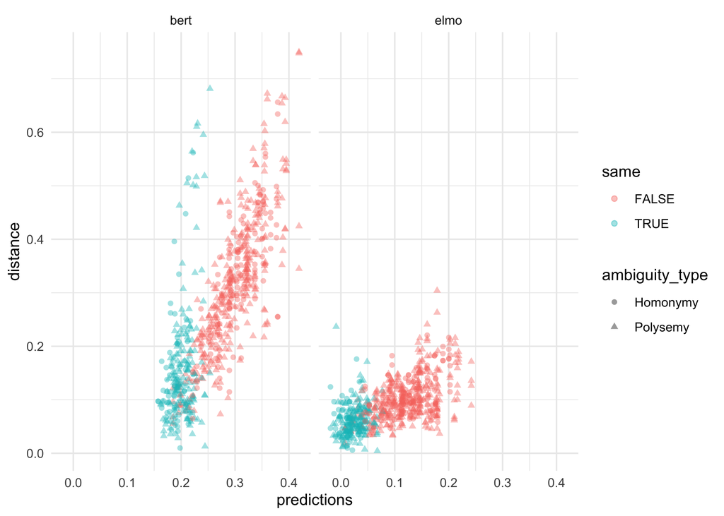

```r
df_distances_reshaped$predictions = predict(model_interaction)

df_distances_reshaped %>%
  ggplot(aes(x = predictions,
             y = distance,
             color = same,
             shape = ambiguity_type)) +
  geom_point(alpha = .4) +
  facet_grid(~model) +
  theme_minimal()
```

# Conclusion

Both BERT and ELMo appear to capture whether two **usages** of a wordform correspond to `same` or `different` senses (as determined by Merriam-Webster/OED): `Cosine Distance` is larger for `different sense` than `same sense` usages.

The relationship between `Cosine Distance` and `Ambiguity Type` (i.e., `Homonymy/Polysemy`) is less clear, however: while the interaction `Ambiguity Type * Same Sense` is trending, it does not appear that `Cosine Distance` is *reliably* larger for different sense `homonyms` than different sense `polysems`.

In future work, we will compare each measure---`Cosine Distance`, as well as `Same Sense` and `Ambiguity Type`---to human judgments of `relatedness`. Ultimately, each measure will be used to predict human behavior (`Accuracy` and `RT`) on a primed sensibility judgment task.